# MY472: Final assignment 2021/22

### Exercise 5 (9 points)

Use `ggplot2` to replicate the bar chart on fully and partially vaccinated people from https://ourworldindata.org/covid-vaccinations as closely as possible with the given data and R functionalities. There is no need to animate the plot, just use the latest static plot and replicate it with `ggplot2.` As these data will change over time, feel free to download the image version from the website that you are going to replicate. Then you can add this image into the repo and afterwards bind it into this markdown e.g. with `![](imagename.png)` as a reference below your own plot.

Note: When you click on `DOWNLOAD` below the plot on the [website](https://ourworldindata.org/covid-vaccinations), you can download the latest image as well as all data.

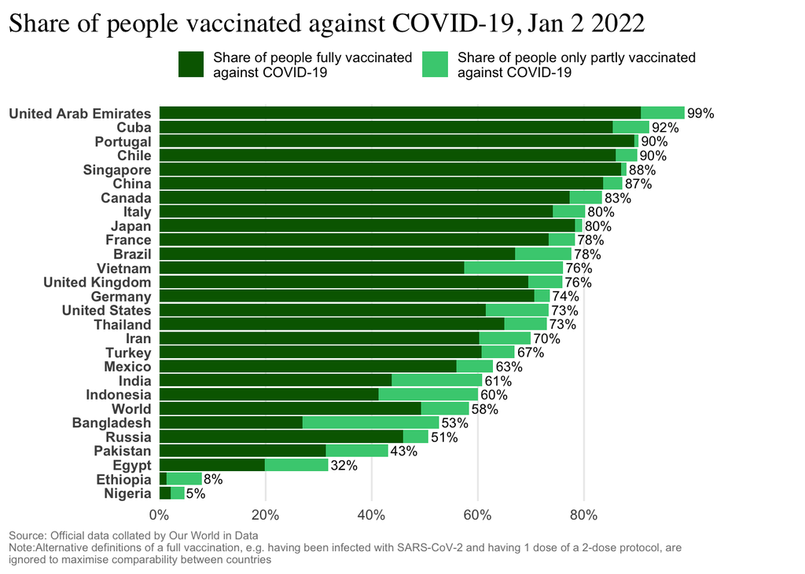

[figure not shown]

```r
# Reading in data
vaccinations <- read.csv("owid-covid-data.csv")

# Identifying columns needed
cols_wanted <- colnames(vaccinations)[3:4]
cols_wanted <- append(cols_wanted,colnames(vaccinations)[42:43])

# Identifying countries needed
countries_selected <- c("Bangladesh", "Brazil", "Canada", "Chile", "China", "Cuba","Egypt","Ethiopia","France",
                        "Germany","India","Indonesia","Iran","Italy","Japan","Mexico","Nigeria","Pakistan",
                        "Philippines","Portugal","Russia","Singapore","Thailand","Turkey","United Arab Emirates",
                        "United Kingdom","United States","Vietnam","World")

# Making necessary data cleaning steps
vaccinations <- vaccinations %>%
  select(all_of(cols_wanted)) %>%
  filter(!is.na(people_fully_vaccinated_per_hundred)) %>%
  filter(location %in% countries_selected) %>%
  group_by(location) %>%
  filter(date == max(date)) %>%
  filter(!is.na(people_vaccinated_per_hundred)) %>%
  mutate(people_partially_vaccinated_per_hundred = people_vaccinated_per_hundred - people_fully_vaccinated_per_hundred) %>%
  arrange(desc(people_vaccinated_per_hundred))


# Pivoting dataframe
vaccinations <- vaccinations %>%
  #select(-people_vaccinated_per_hundred, -date) %>%
  pivot_longer(c(people_partially_vaccinated_per_hundred, people_fully_vaccinated_per_hundred), names_to = "type_of_vaccination", values_to = "vaccinations_per_hundred")

#Creating ordering of data
vaccinations$type_of_vaccination <- factor(vaccinations$type_of_vaccination, levels = c("people_partially_vaccinated_per_hundred","people_fully_vaccinated_per_hundred"))

# Creating data for labels
vac_summary <- vaccinations %>%
  group_by(location) %>%
  summarise(max_people_vaccinated_per_hundred = max(people_vaccinated_per_hundred))

# Creating chart
ggplot(vaccinations, aes(x = reorder(location, vaccinations_per_hundred/100, sum), y = vaccinations_per_hundred/100))+
  geom_col(aes(fill = type_of_vaccination)) + scale_fill_manual(labels = c("Share of people only partly vaccinated\nagainst COVID-19","Share of people fully vaccinated\nagainst COVID-19"), values = c("seagreen3","darkgreen"),guide = guide_legend(reverse = TRUE))+ coord_flip() +
  labs(title = "Share of people vaccinated against COVID-19, Jan 2 2022", caption ="Source: Official data collated by Our World in Data\nNote:Alternative definitions of a full vaccination, e.g. having been infected with SARS-CoV-2 and having 1 dose of a 2-dose protocol, are \nignored to maximise comparability between countries") +
  geom_text(data = vac_summary,
            aes(x = reorder(location, max_people_vaccinated_per_hundred),
                y = max_people_vaccinated_per_hundred/100,
                label = scales::percent(x=max_people_vaccinated_per_hundred/100,accuracy=1L)),
            hjust=(-0.1),
            size=3) +
  scale_y_continuous(labels = scales::percent, breaks=c(0,0.2,0.4,0.6,0.8), expand=c(0.0,0.0)) +
  expand_limits(y = c(0,1.2))+
  theme_minimal() +
  theme(plot.title = element_text(family="Times", vjust=0.2, size=17),
        plot.title.position = "plot",
        plot.caption.position =  "plot",
        axis.title.y=element_blank(),
          axis.title.x=element_blank(),
          axis.text.y = element_text(face="bold"),
          legend.position = "top",
          legend.justification='left',
          legend.direction='horizontal',
          legend.title = element_blank(),
          legend.text.align = 0,
          panel.grid.major.y=element_blank(),
          plot.caption = element_text(hjust = 0, color="gray50",size=7),
          panel.grid.minor.x=element_blank())
```

### Exercise 6 (9 points)

Create an SQLite database called `fb-posts.sqlite` and connect to it with the `DBI` package. Store the file `posts.csv` (without any editing in R) in the database as its only table `posts`. The table may only contain the original information from `posts.csv`, all computations in this exercise have to be done with SQL.

With **only a single** (which is the main challenge in this exercise) SQL query through `DBI`, replicate the output from Exercise 1. This means that the query should return the same 10 lowest `mad_clr` column values with the associated screen names as in Exercise 1.

Hint: There is no need to transform screen names to lower case letters here to replicate the outcome from Exercise 1. The command “LIKE” is not case-sensitive in SQLite, so you can just use “LIKE” to find all screen names that contain terms such as “blum” etc. regardless of whether characters are upper or lower case.

```r
#Writing table
db <- dbConnect(RSQLite::SQLite(), "fb-posts.sqlite")
posts <- read.csv("data/posts.csv", stringsAsFactors=FALSE)
dbWriteTable(db, "posts", posts, overwrite=TRUE)


# Running single query
dbGetQuery(db,
  "SELECT screen_name, CASE
    WHEN screen_name LIKE '%blum%'  THEN ABS(clr - 0.25*average_clr)
    WHEN (screen_name LIKE '%mce%' AND SUBSTR(date, 9, 10) = '10' )   THEN ABS(clr - 0.5*average_clr)
  ELSE ABS(clr - average_clr)
  END AS mad_clr
  FROM (SELECT *, ((1.0 * comments_count)/likes_count) AS clr,
  AVG((1.0 * comments_count)/likes_count) OVER (PARTITION BY screen_name) AS average_clr
  FROM posts
  WHERE likes_count > 0)
  WHERE mad_clr > 0
  ORDER BY mad_clr
  LIMIT 10 ")
```

```
##               screen_name      mad_clr
## 1           RichardShelby 5.411617e-05
## 2   CongressmanBillFoster 1.097838e-04
## 3          RepStephMurphy 1.186369e-04
## 4           HurdOnTheHill 1.473554e-04
## 5  CongressmanAndreCarson 1.525540e-04
## 6  CongressmanClayHiggins 1.687448e-04
## 7          reprichardneal 2.099468e-04
## 8             RepMcEachin 2.122892e-04
## 9          senatormikelee 2.168587e-04
## 10      senatorchriscoons 3.121268e-04
```

### Exercise 7 (22 points)

The New York Times (NYT) APIs offer a rare free opportunity to analyse data since 1851 (the year of the first issue of the paper) and thereby a multitude of historical events or also topics over time. You can e.g. use the “Article Search API” to search through all articles without obtaining their texts explicitly. Alternatively, you could use the “Archive API” which allows to download all article headlines and lead paragraphs/snippets for a given month (and through iteration potentially for a range of years). While this does not allow to obtain the full articles, it still allows to download a lot of textual data and thereby do own textual analysis. There are also a range of other NYT APIs which you can find [here](https://developer.nytimes.com/apis) if these are of greater interest to you. Think about a topic you are very interested in and use the NYT API to develop and present a coherent analysis of the topic. This could be done with basic quantitative text analysis in `quanteda`, visualisations e.g. of keyword frequencies and time series with `ggplot2`, word clouds, written discussion, use of further R packages, etc.

More creative and extensive solutions will receive higher marks here. Note, however, that here already a single API such as the “Archive API” can be used to obtain very large amounts of data here which can be sufficient for the most detailed analysis even beyond the scope of this assignment.

Hint: You might find the code examples from week 5 helpful for this exercise. Should you choose to use the “Archive API” to download some data, the last section in the file `02-nytimes-api.Rmd` illustrates how you can transform its output into a data frame. Usually the main available text is contained in the headline, abstract, lead_paragraph, and/or snippet columns (depending on which month/year you download some of these will be empty or the same). Note that the headline information in the data frame is nested and can be accessed with `df$headline$main`. Furthermore, `02-nytimes-api.Rmd` also gives an introduction to using the “Article Search API”.

#### In this section I will explore how 5 American historical icons, (ie. people who currently appear on US currency, or will soon appear on US currency ) are referenced in the NYT.

#### Due to the amount of data collected, the data has been saved as csv files and the scraping scripts below do not run for Q7.

#### In the first scraping section, I scrape how many articles mention each historical figures in each year, since 1970.

```r
# Setting key variables

base_url <- "http://api.nytimes.com/svc/search/v2/articlesearch.json"
on_money <- c("Andrew Jackson", "George Washington", "Abraham Lincoln", "Harriet Tubman", "Sacagawea")

# This code below is adapted from the lecture/course materials
# This code below creates two functions which scrape the number of mentions from the NYT API.
nyt_count <- function(q, date1, date2) {

  # Get the return of the request
  r <- GET(base_url, query = list(q = q,
                                  "api-key" = authentication$apikey_NYT,
                                  "begin_date" = date1,
                                  "end_date" = date2))

  # Add a check whether rate limit was hit and retry until status code OK
  while (r$status_code != 200){
    message("Error occured. Retry after 10 seconds..")
    Sys.sleep(10) # Wait 10 seconds
    r <- GET(base_url, query = list(q = q,
                                    "api-key" = authentication$apikey_NYT,
                                    "begin_date" = date1,
                                    "end_date" = date2))

  }

  # Parse the return into R once no error
  json <- content(r, "parsed")

  # Return the article count
  return(json$response$meta$hits)
}

nyt_dates_count <- function(q, init, end, by){
  # Note that init and end are now date objects and we can create a sequence with them
  dates <- seq(from = init, to = end, by = by)
  dates <- format(dates, "%Y%m%d") # changing date format to match NYT API date format
  counts <- rep(NA, length(dates)-1)

  # Loop over periods
  for (i in 1:(length(dates)-1)) { ## note the -1 here
    # Update to track progress
    message(dates[i])
    # Retrieve count
    counts[i] <- nyt_count(q = q, date1 = dates[i],
                           date2 = dates[i + 1])
    # Wait 6 seconds between requests as only 10 requests per minute allowed
    Sys.sleep(6)
  }

  # Now the function also returns a dataframe with two columns: date & count
  df <- data.frame(name=rep(q,length(counts)), date = as.Date(dates[-length(dates)], format = "%Y%m%d"), count = counts)
  return(df)
}



# Running the functions for each character
total_mentions <- data.frame(name=c(), date = c(), count = c())
for (i in 1:length(on_money)){
  total_mentions <- rbind(total_mentions, nyt_dates_count(q = on_money[i], init = as.Date("1970/01/01"),
                          end = as.Date("2021/12/31"), by = "year"))
}
```

#### The second scraping section identifies, for each figure, the year that the most articles mentioned their name. It collects data (ie. headline and wordcount) on each article for that year, for that figure.

```r
#Finding the year that each figure had the most mentions, articles in these years will be scraped for that figure
years_most_mentions <- total_mentions %>%
  group_by(name) %>%
  filter(count == max(count)) %>%
  mutate(end_date = date %m+% years(1))

# Adjusting so our script only searches for 1000 results for George Washington
years_most_mentions$number_of_pages <- if_else(years_most_mentions$name == "George Washington", 100, years_most_mentions$count/10)
years_most_mentions$number_of_pages[3]

#Creating an empty dataframe
article_info <- data.frame(name=c(), headline=c(), word_count = c())

#Creating loop that runs for each individual and scrapes wordcount and headline for each article that mentions them
for (i in 1:dim(years_most_mentions)[1]){
  page_number = as.integer(0)
  message(years_most_mentions$name[i])
  while (page_number < as.integer(years_most_mentions$number_of_pages[i])){
    page_number <- page_number + 1
    message(page_number)
    r <- GET(base_url, query = list(q = years_most_mentions$name[i],
                                  "api-key" = authentication$apikey_NYT,
                                  "page" = page_number,
                                  "begin_date" = years_most_mentions$date[i],
                                  "end_date" = years_most_mentions$end_date[i]))
    results_json <- content(r, "parsed")
    for (article in 1:length(results_json$response$docs)){
      #Dealing with instances where the data is not provided
      headline <- if_else(is.null(results_json$response$docs[[article]]$headline$print_headline),"Headline not provided",results_json$response$docs[[article]]$headline$print_headline)
      word_count <- if_else(is.null(results_json$response$docs[[article]]$word_count),-999,
      as.numeric(results_json$response$docs[[article]]$word_count))

      #Updating dataframes
      temp_df <- data.frame(name =  years_most_mentions$name[i], headline = headline, word_count=word_count)
      article_info <- rbind(article_info,temp_df)

      Sys.sleep(6)
    }

  }
}
```

#### Showing graphs on article mentions since 1970

```r
# Reading in saved data
total_mentions <- read_csv('total_mentions.csv',show_col_types = FALSE)
```

```
## * `` -> ...1
```

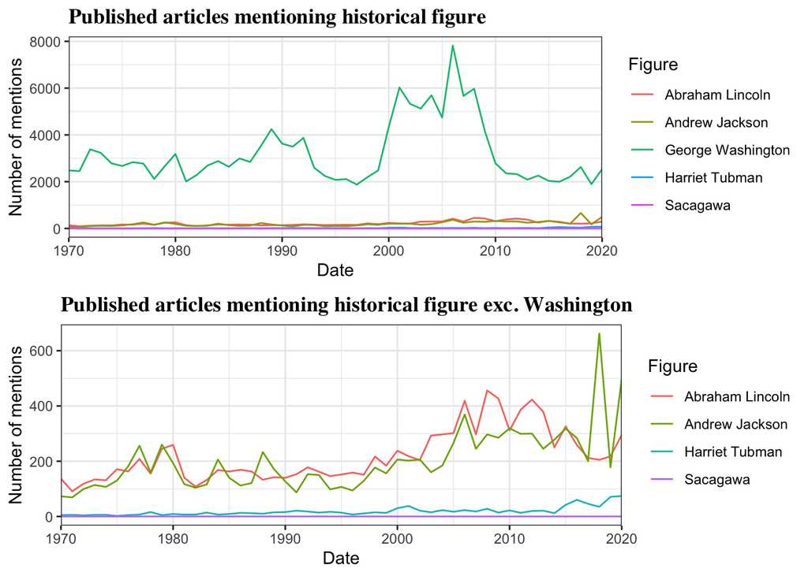

```r
# Creating two graphs. Given that George Washington is such an outlier, we have created one including him and one excluding him, for comparison.
plt_with_wash <- ggplot(total_mentions, aes(x=date,y=count, group=name, color=name)) +
  geom_line() +
  scale_colour_discrete(name = "Figure") +
  scale_x_date(expand=c(0,0)) +
  theme_bw() +
  labs(title = "Published articles mentioning historical figure", y = "Number of mentions", x="Date") +
  theme(plot.title = element_text(family="Times", face="bold"))

plt_without_wash <- ggplot(total_mentions %>%  filter(name!= "George Washington"), aes(x=date,y=count, group=name, color=name)) +
  geom_line() +
  scale_colour_discrete(name = "Figure") +
  scale_x_date(expand=c(0,0)) +
  theme_bw() +
  labs(title = "Published articles mentioning historical figure exc. Washington", y = "Number of mentions", x="Date") +
  theme(plot.title = element_text(family="Times", face="bold"))

# Printing graphs
grid.arrange(plt_with_wash, plt_without_wash, nrow=2)
```

#### These graphs indicate that George Washington is referenced far more than the other historical figures.

#### We see a big increase in mentions of Andrew Jackson in recent years. We could hypothesise that this could be due to the analogies made between Jackson and Trump, or it could be due to the fact that he is due to be removed from US currency. Jackson will be replaced by Harriet Tubman on the $20 bill, and accordingly we see an increase in Tubman’s mentions in recent years.

#### In the next piece of analysis we show a distribution of article word count by historical figure:

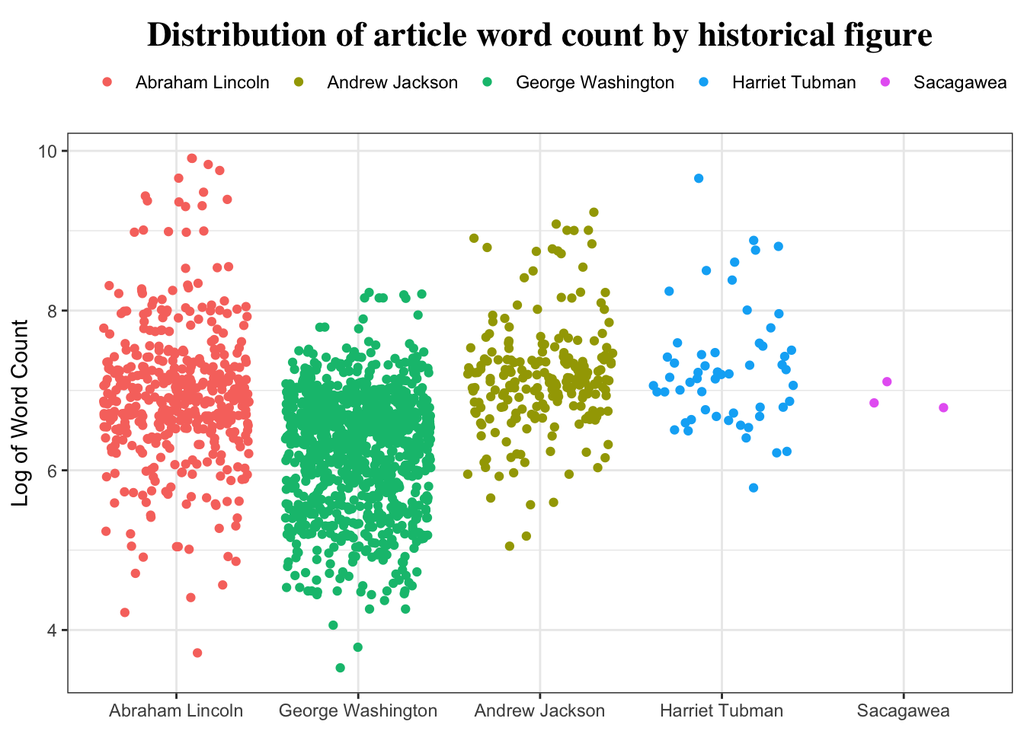

```r
article_info <- read.csv('article_info.csv')
ggplot(article_info %>% filter(word_count != -999), aes(x=reorder(name,-word_count,sum), y=log(word_count), colour=name)) + geom_jitter() +
  theme_bw() +
  labs(title = "Distribution of article word count by historical figure", y = "Log of Word Count") +
  theme(plot.title = element_text(family="Times", hjust= 0.5, vjust=-0.4, face="bold", size=17),
        legend.position = "top",
          legend.justification='left',
        legend.title = element_blank(),
        axis.title.x = element_blank()
        )
```

#### We see that George Washington tends to be mentioned in articles which are shorter, when compared to the other figures included in the sample.

#### In the next section we complete some text analysis with quanteda:

```r
# Cleaning data ready for analysis
article_info_cleaned <-article_info %>%
  filter(headline != "Headline not provided" & word_count != -999) %>%
  group_by(name) %>%
  mutate(counter = row_number(name)) %>%
  mutate(doc_id = paste0(name,"_",counter))

# Creating vectors of headlines and docvars
headlines <- article_info_cleaned$headline
names(headlines) <- article_info_cleaned$doc_id

# Creating corpus, with docvars
article_corpus <- corpus(headlines, docvars = data.frame(names=names(headlines)))
docvars(article_corpus, "Figure") <- article_info_cleaned$name

#  Creating dfm
article_dfm <- article_corpus %>%
    tokens(remove_punct = TRUE) %>%
    tokens_remove(stopwords("en")) %>%
    dfm() %>%
    dfm_group(groups = Figure)

# Identifying top features across all articles
topfeatures(article_dfm,20)
```

```
##    washington        herald international       tribune          bush
##           111           111           110           110            85
##      americas        george           u.s           new  celebrations
##            77            63            55            53            50
##          paid      weddings        notice        deaths         obama
##            49            49            48            47            37
##        letter          iraq    basketball       college           war
##            36            35            35            31            27
```

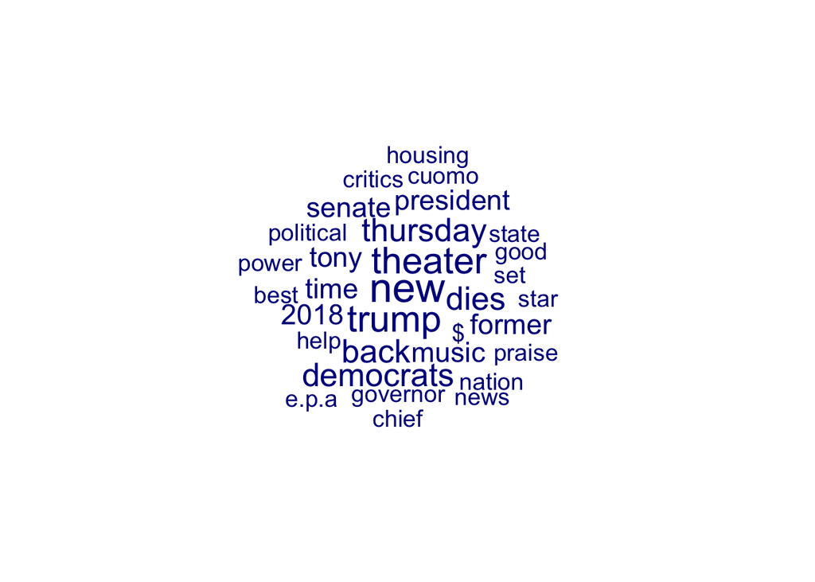

```r
# Creating word clouds for each president (as these figures have sufficient data)
# Andrew Jackson word cloud
textplot_wordcloud(dfm_subset(article_dfm, Figure == "Andrew Jackson"),
                   rotation=0, min_size=.75, max_size=3, max_words=50)
```

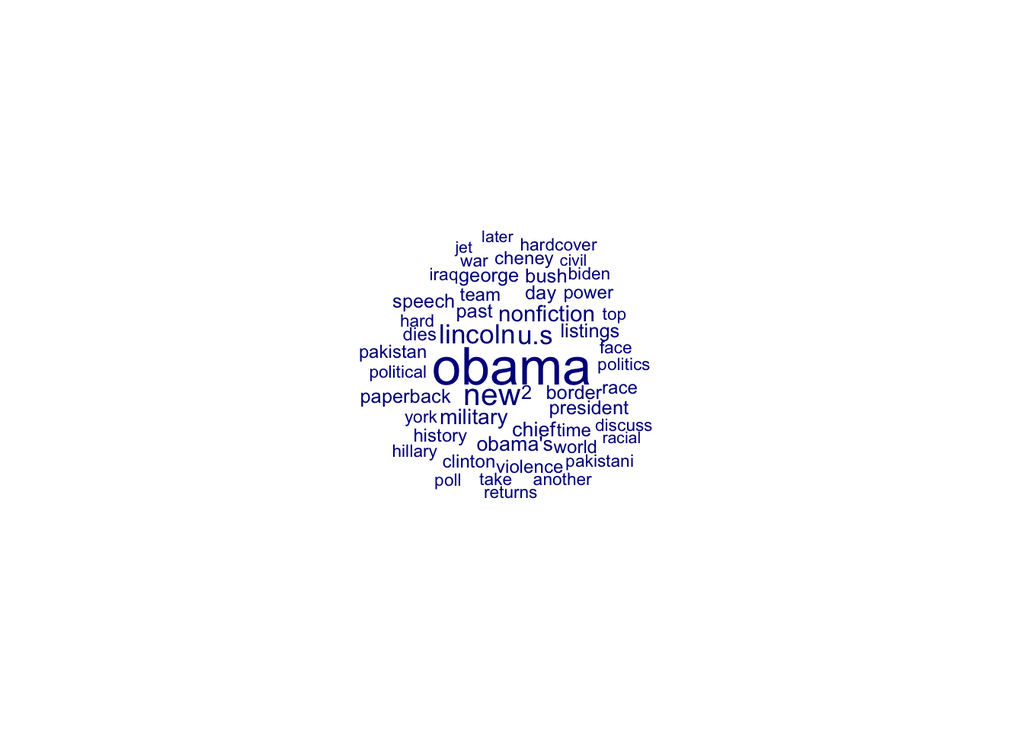

```r
# Abraham Lincoln word cloud
textplot_wordcloud(dfm_subset(article_dfm, Figure == "Abraham Lincoln"),
                   rotation=0, min_size=.75, max_size=3, max_words=50)
```

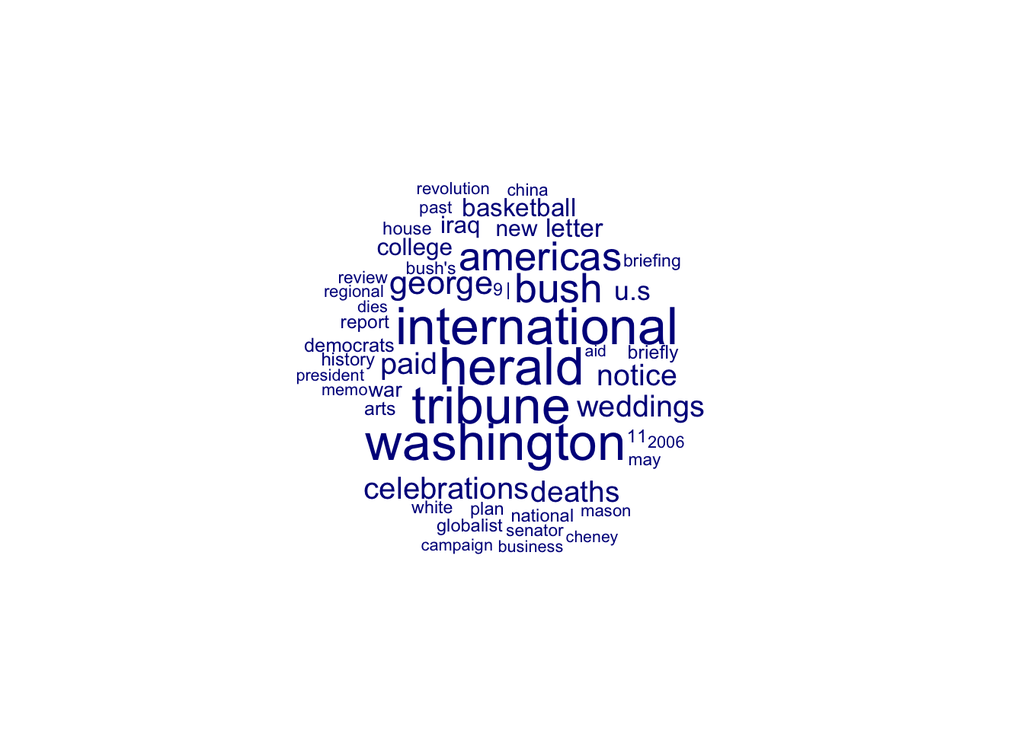

```r
# George Washington word cloud
textplot_wordcloud(dfm_subset(article_dfm, Figure == "George Washington"),
                   rotation=0, min_size=.75, max_size=3, max_words=50)
```

#### From this analysis above we can conclude some key points:

#### Some political topics/figures seem of particular salience, eg. Iraq and Obama.

#### Another point is that historical presidents tend to be mentioned along with more recent presidents.

#### For instance: Jackson is mentioned along with Trump; Lincoln is mentioned with Obama; Washington is mentioned along with Bush.

### Exercise 8 (35 points)

This exercise is an independent project that allows you to illustrate and analyse data about a topic of your choice. You will first obtain data from APIs through R, organise and store it in a relational database, and then examine and present the topic through computations and visualisations.

1. Read through this [list](https://github.com/public-apis/public-apis) of APIs mentioned in the lecture and choose any of the API(s) in which you are particularly interested. Make sure that the API(s) you choose contain data for a coherent analysis later on.
2. Obtain the relevant data from your chosen API(s) **through R** with packages such as `httr` or others. Then process the data in R e.g. with the typical `tidyverse` functionalities.
3. Create a `SQLite` database, and store at least two tables into a well structured and thought through relational database (no need to store any data in the database that you do not need in your later analysis). Run SQL queries which return the first five rows and all columns of your tables (to give the reader a preview of what you have collected). Also run SQL queries to return the total amount of rows of your tables.
4. Demonstrate which of the tables can be joined. Return **only** the first five rows of the joined tables, and also return the total number of rows in the joined tables with a query.
5. Now query the database with SQL to obtain data for the main analysis of this exercise. Afterwards you can do all subsequent steps with R. Analyse and illustrate your data e.g. numerically with packages such as `dplyr`, through visualisations based on `ggplot2`, quantitative text analysis with `quanteda`, other packages, and/or written discussion.

More creative and extensive projects that obtain and combine data from more than one API into a clean database, and then present and discuss the data with a coherent and detailed analysis will receive higher marks here.

#### I will therefore be using the Wikidata API, the Guardian API and the Google Books API to identify references and extract information on these references.

#### Note: To ensure that the script runs on knitting for Q8 I have not taken all data from the Guardian or Google API. This means that the analysis below ultimately uses an incomplete sample. Whilst this undermines the analysis to an extent, it seemed a sensible decision in the context of the assignment.

#### Downloading newspaper article data from Guardian API

```r
author_ref <- data.frame(Author=c("Charles Dickens", "Jane Austen", "Robert Burns") ,
           Tag=c("books/charlesdickens","books/janeausten","books/robertburns"))

uk_article_results <-  data.frame(author=c(),
                                  id = c(),
                                  sectionName = c(),
                                  webPublicationDate = c(),
                                  webTitle = c(),
                                  webUrl = c(),
                                  apiUrl = c(),
                                  isHosted = c(),
                                  pillarId = c(),
                                  pillarName = c(),
                                  tags= c(),
                                  headline = c(),
                                  body =c()
                                  )

base_url <- "https://content.guardianapis.com/search"

# Scraping Guardian articles for each author
for (i in 1:dim(author_ref)[1]){
  page_number <- 0
  tags_to_search = author_ref$Tag[i]
  author_to_search_for <- author_ref$Author[i]
  while (page_number <= 5){
    page_number <- page_number + 1
    r <- GET(base_url, query = list(tag=tags_to_search,
                                    q = author_to_search_for,
                                  "api-key" = authentication$apikey_guardian,
                                  "page" = page_number,
                                  "show-fields"="body,headline",
                                  "show-tags" = "keyword"))
    results_json <- content(r, "parsed")

    json <- content(r, "parsed")
    for (article in json$response$results){
      #print(article$id)
      concat_tags = "0"
      for (i in article$tags){
        if (concat_tags == "0"){
          concat_tags = i$id
        }
        else{
            concat_tags<- paste0(concat_tags,",",i$id)
        }
      }

      df <- data.frame(author= author_to_search_for,
                       id = article$id,
                      sectionName = article$sectionName,
                      webPublicationDate = article$webPublicationDate,
                      webTitle = article$webTitle,
                      webUrl = article$webUrl,
                      apiUrl = article$apiUrl,
                      isHosted = article$isHosted,
                      pillarId = article$pillarId,
                      pillarName = article$pillarName,
                      tags= concat_tags,
                      headline = article$fields$headline,
                      body = article$fields$body
                       )
      uk_article_results <- rbind(uk_article_results, df)
    }
  Sys.sleep(2)
  }
}
```

#### Downloading information on the authors’ notable works from Wikidata API

```r
# Creating queries for scraping
endpoint <- "https://query.wikidata.org/sparql"
query_dickens <- ('SELECT ?book ?bookLabel
    WHERE
    {
      wd:Q5686 wdt:P800 ?book.
      SERVICE wikibase:label {bd:serviceParam wikibase:language "en".
      }
    }
')
query_austen <- ('SELECT ?book ?bookLabel
    WHERE
    {
      wd:Q36322 wdt:P800 ?book.
      SERVICE wikibase:label {bd:serviceParam wikibase:language "en".
      }
    }
')
query_burns <- ('SELECT ?book ?bookLabel
    WHERE
    {
      wd:Q81960 wdt:P800 ?book.
      SERVICE wikibase:label {bd:serviceParam wikibase:language "en".
      }
    }
')

useragent <- paste("osconr", R.version.string)


# Scraping Wikidata on authors' notable works
dickens_wiki <- SPARQL(endpoint,query_dickens,curl_args=list(useragent=useragent))
dickens_books <- dickens_wiki$results
dickens_books$author <- "Charles Dickens"
austen_wiki <- SPARQL(endpoint,query_austen,curl_args=list(useragent=useragent))
austen_books <- austen_wiki$results
austen_books$author <- "Jane Austen"
burns_wiki <- SPARQL(endpoint,query_burns,curl_args=list(useragent=useragent))
burns_books <- burns_wiki$results
burns_books$author <- "Robert Burns"

#Cleaning and combining wikidata into one dataframe
notable_works <- rbind(dickens_books,austen_books,burns_books)
notable_works$bookLabel <- gsub('"@en', '',notable_works$bookLabel)
notable_works$bookLabel <- gsub('"', '',notable_works$bookLabel)
notable_works <- select(notable_works, -book)
colnames(notable_works)[1] <- "notableWork"
```

#### Downloading data from the Google Books API on books that relate to the authors

```r
# Preparing information for querying
g_url <- 'https://www.googleapis.com/books/v1/volumes'

uk_book_results <-  data.frame(author=c(),
                  title = c(),
                  textSnippet = c(),
                  description = c(),
                  publishedDate = c()
                  )

#Running querying information
for (i in 1:dim(author_ref)[1]){
  search_index <- -10
  author_to_search_for <- author_ref$Author[i]
  while (search_index < 100){
    search_index <- search_index +10
    g <- GET(g_url, query = list(q = (author_to_search_for), printType="books", startIndex=search_index, "api-key" = authentication$apikey_googlebooks))
    g_json <- content(g, "parsed")

    for (book in g_json$items){
      # Dealing with missing information
      title <- if_else(is.null(book$volumeInfo$title),"Title not provided",book$volumeInfo$title)
      textSnippet = if_else(is.null(book$searchInfo$textSnippet),"Snippet not provided",book$searchInfo$textSnippet)
      description = if_else(is.null(book$volumeInfo$description),"Description not provided",book$volumeInfo$description)
      publishedDate = if_else(is.null(book$volumeInfo$publishedDate),"Published date not provided",book$volumeInfo$publishedDate)

      # Appending data to dataframe
      df <- data.frame(author=author_to_search_for,
                       title = title,
                             textSnippet =   textSnippet,
                                description = description,
                                publishedDate = publishedDate)

        uk_book_results <- rbind(uk_book_results, df)
    }
  Sys.sleep(2)
  }
}
```

#### The code below cleans and manipulates the data and then adds it to the database.

#### Note: In the loop below articles and books are linked to a notable work by the author. A simplifying assumption is made that a text excerpt only refers to one notable work. Whilst many of the articles/book blurbs actually do make reference to more than one notable work, this assumption was made to make the data structures more feasible and to facilitate analysis.

```r
#Checking to see which works appear in which headline
for (writer in author_ref$Author){
  temp_df <- notable_works %>% filter(author == writer)
  for (work in 1:dim(temp_df)[1]){
    uk_article_results$notableWork <- if_else(grepl(temp_df$notableWork[work], uk_article_results$body), temp_df$notableWork[work], uk_article_results$notableWork)
    uk_book_results$notableWork <- if_else(grepl(temp_df$notableWork[work], uk_book_results$textSnippet), temp_df$notableWork[work], uk_book_results$notableWork)
  }
}

#Removing articles and books which do not have a clear reference to any notable work of the author:
uk_article_results <- uk_article_results %>% filter(!is.na(notableWork))
uk_book_results <- uk_book_results %>% filter(!is.na(notableWork))


#  Changing data format and removing unnecessary columns
uk_article_results$publicationYear <- as.numeric(substr(uk_article_results$webPublicationDate,1,4))
uk_article_results <- select(uk_article_results, all_of(c("id", "publicationYear","headline","body","notableWork")))
uk_book_results$publicationYear <- as.numeric(substr(uk_book_results$publishedDate,1,4))
uk_book_results <- select(uk_book_results, -all_of(c("author", "publishedDate")))


# Adding three tables to the database
db <- dbConnect(RSQLite::SQLite(), "authors.sqlite")
dbWriteTable(db, "notable_works", notable_works, overwrite=TRUE)
dbWriteTable(db, "uk_article_results", uk_article_results, overwrite=TRUE)
dbWriteTable(db, "uk_book_results", uk_book_results, overwrite=TRUE)

#Printing first 5 rows of notable_works table
dbGetQuery(db,
  "SELECT *
  FROM notable_works
  LIMIT 5")
```

```
##            notableWork          author
## 1    A Christmas Carol Charles Dickens
## 2         Oliver Twist Charles Dickens
## 3    David Copperfield Charles Dickens
## 4   Great Expectations Charles Dickens
## 5 A Tale of Two Cities Charles Dickens
```

```r
# Listing column names of uk_article_results
dbListFields(db, "notable_works")
```

```
## [1] "notableWork" "author"
```

```r
#Printing row count of notable_works table
dbGetQuery(db,
  "SELECT COUNT(*)
  FROM notable_works")
```

```
##   COUNT(*)
## 1       25
```

```r
#Printing first 5 rows of uk_article_results table
dbGetQuery(db,
  "SELECT *
  FROM uk_article_results
  LIMIT 5")
```

```
##                                                                                                                          id
## 1                                          books/2021/aug/22/the-turning-point-review-how-charles-dickens-built-bleak-house
## 2                                                         commentisfree/2021/dec/25/it-wouldnt-be-christmas-without-dickens
## 3                              books/2021/dec/17/a-christmas-carols-lesser-known-successor-gets-its-moment-in-the-spotlight
## 4                                                             tv-and-radio/2021/sep/03/a-great-theme-tune-without-the-drama
## 5 culture/2021/dec/11/theres-always-been-an-affinity-between-christmas-and-ghosts-mark-gatiss-on-the-joy-of-festive-frights
##   publicationYear
## 1            2021
## 2            2021
## 3            2021
## 4            2021
## 5            2021
##                                                                                                    headline
## 1                                          The Turning Point review – how Charles Dickens built Bleak House
## 2                                                                  It wouldn’t be Christmas without Dickens
## 3                              A Christmas Carol’s lesser-known successor gets its moment in the spotlight
## 4                                                                      A great theme tune without the drama
## 5 ‘There’s always been an affinity between Christmas and ghosts’: Mark Gatiss on the joy of festive frights
##                                                                                                                                                                                                                                                                                                          …
## 1                                                                                                                                                                                        <p>The problem with most biographies is that they tend to have only two pace settings. There is the plod of the …
## 2                                                                                                                                                                                                                                                                                                        …
## 3                                                                                                                                                                                                                                                                                                        …
## 4                                                                                                                                                                                                                                                                                                        …
## 5 <p>Close the curtains. Light the fire. Then prepare to be terrified; it’s Christmas. For although the word “cosy” may be closely tied to festivities at this time of year, so it seems is the word “ghost”.</p> <p>In northern Europe people understandably cope with the shorter days and darker eveni…
##         notableWork
## 1       Bleak House
## 2 A Christmas Carol
## 3       Bleak House
## 4      Oliver Twist
## 5         Halloween
```

```r
# Listing column names of uk_article_results
dbListFields(db, "uk_article_results")
```

```
## [1] "id"              "publicationYear" "headline"        "body"
## [5] "notableWork"
```

```r
#Printing row count of uk_article_results table
dbGetQuery(db,
  "SELECT COUNT(*)
  FROM uk_article_results")
```

```
##   COUNT(*)
## 1      127
```

```r
#Printing first 5 rows of uk_book_results table
dbGetQuery(db,
  "SELECT *
  FROM uk_book_results
  LIMIT 5")
```

```
##                            title
## 1            Pictures from Italy
## 2          Charles Dickens Books
## 3 The Charles Dickens Collection
## 4                Charles Dickens
## 5      Classic Charles Dickens 2
##                                                                                                                                                                                                                                            textSnippet
## 1 Charles Dickens (1812-1870) has produced some of the most memorable writings in the English language, including such well known works as &quot;A Christmas Carol, Sketches by Boz, A Tale of Two Cities, Oliver Twist, Daivid Copperfield, Great ...
## 2                                                          The Chimes A Goblin Story of Some Bells that Rang an Old Year Out and a New Year In, a short novel by Charles Dickens, was written and published in 1844, one year after A Christmas Carol.
## 3                                                                           A collection of the three best Charles Dickens novels: A Christmas Carol, A Tale of Two Cities, and Oliver Twist. Charles Dickens was an English writer and social critic.
## 4                      This superb collection of classic Victorian literature features the most notable works of Charles Dickens, including Oliver Twist (1839), A Christmas Carol (1843), A Tale of Two Cities (1859), and Great Expectations (1861).
## 5                                       This timeless collection brings together his most iconic novels. David Copperfield Hard Times The power of Dickens is so amazing that the reader at once becomes his captive.&#39; William Makepeace Thackeray
##                                                                                                                                                                                                                                                                                                          …
## 1                                                                                                                                                                                                                                                                                                        …
## 2                                                                                                                                                                                                                                                                                                        …
## 3 A collection of the three best Charles Dickens novels: A Christmas Carol, A Tale of Two Cities, and Oliver Twist. Charles Dickens was an English writer and social critic. He created some of the world's best-known fictional characters and is regarded by many as the greatest novelist of the Victo…
## 4                                                                                                                                                                                              This superb collection of classic Victorian literature features the most notable works of Charles Dickens,…
## 5                                                                                                                                                                                                                                                                                                        …
##            notableWork publicationYear
## 1 A Tale of Two Cities            1998
## 2    A Christmas Carol            2021
## 3 A Tale of Two Cities            2018
## 4 A Tale of Two Cities            2018
## 5           Hard Times            2012
```

```r
# Listing column names of uk_book_results
dbListFields(db, "uk_book_results")
```

```
## [1] "title"           "textSnippet"     "description"     "notableWork"
## [5] "publicationYear"
```

```r
#Printing row count of uk_book_results table
dbGetQuery(db,
  "SELECT COUNT(*)
  FROM uk_book_results")
```

```
##   COUNT(*)
## 1       30
```

#### In section 4 I join the tables. I have one table, *notable_works*, which is a list of all the notable works for each author. I can therefore join this with the other tables to see which articles and books mention/discuss these works. Author is only stored in the notable_works table, as this ensures unnecessary strings are not kept in the other tables.

```r
# Joining uk_article_results with notable_works
dbGetQuery(db,
  "SELECT notable_works.author, uk_article_results.*
  FROM notable_works
  JOIN uk_article_results ON notable_works.notableWork = uk_article_results.notableWork
  LIMIT 5")
```

```
##            author
## 1 Charles Dickens
## 2 Charles Dickens
## 3 Charles Dickens
## 4 Charles Dickens
## 5 Charles Dickens
##                                                                                                    id
## 1             books/2019/dec/18/charles-dickenss-final-christmas-turkey-lost-by-great-western-railway
## 2         books/2021/dec/28/a-christmas-carol-is-not-cosy-and-its-angry-message-should-still-haunt-us
## 3                   books/2021/jun/09/top-10-novels-told-in-a-single-day-james-clammer-insignificance
## 4 commentisfree/2019/dec/23/the-guardian-view-on-the-new-scrooge-a-charismatic-antihero-for-christmas
## 5                                   commentisfree/2021/dec/25/it-wouldnt-be-christmas-without-dickens
##   publicationYear
## 1            2019
## 2            2021
```

[output cut: 21 more lines]

```r
#Counting rows of joined table
dbGetQuery(db,
  "SELECT COUNT(*)
  FROM notable_works
  JOIN uk_article_results ON notable_works.notableWork = uk_article_results.notableWork")
```

```
##   COUNT(*)
## 1      127
```

```r
# Joining uk_book_results with notable_works
dbGetQuery(db,
  "SELECT notable_works.author, uk_book_results.*
  FROM notable_works
  JOIN uk_book_results ON notable_works.notableWork = uk_book_results.notableWork
  LIMIT 5")
```

```
##            author                                              title
## 1 Charles Dickens     A Christmas Carol: Annotation-Friendly Edition
## 2 Charles Dickens                              Charles Dickens Books
## 3 Charles Dickens           The Christmas Stories of Charles Dickens
## 4 Charles Dickens          Charles Dickens: Adapted by Neil Bartlett
## 5 Charles Dickens Great Expectations & A Christmas Carol (Annotated)
##                                                                                                                                                                                                                                                textSnippet
## 1           **The accompanying A Christmas Carol: Revision Guide for GCSE will be out in April!** This Annotation-Friendly edition has: - Large spaces between lines for annotations - Large outer margins - Pages at the end of each chapter for note ...
## 2                                                              The Chimes A Goblin Story of Some Bells that Rang an Old Year Out and a New Year In, a short novel by Charles Dickens, was written and published in 1844, one year after A Christmas Carol.
## 3                                                                                      This collection includes the following books: A Christmas Carol The Chimes The Cricket on the Hearth The Battle of Life The Haunted Man and the Ghost&#39;s Bargain
## 4 This collection includes: Great Expectations: From its opening image of little Pip, alone on the windswept marshes, to the haunted darkness of mad Miss Haversham&#39;s cobweb-strewn lair, this adaptation takes its audience on a journey right to ...
## 5             Many vintage books are increasingly scarce and expensive. We published this volume in an affordable, modern, high-quality edition complete with a biography of the author.Includes: A Christmas Carol (1843)Great Expectations (1867 edition
##                                                                                                                                                                                                                                                                                                          …
## 1                                                                                                                                                                                                                                                                                                        …
## 2                                                                                                                                                                                                                                                                                                        …
## 3                                                                                                                                                                                                                                                                                                        …
## 4 Using only Charles Dickens’ extraordinary words and a chameleon ensemble of actors, Neil Bartlett's powerful stage versions of Dickens have gathered wide critical acclaim. This collection includes: Great Expectations: From its opening image of little Pip, alone on the windswept marshes, to the …
## 5                                                                                                                                                                                                                                                                                                        …
##          notableWork publicationYear
## 1  A Christmas Carol            2019
## 2  A Christmas Carol            2021
## 3  A Christmas Carol            2016
## 4 Great Expectations            2014
## 5 Great Expectations            2020
```

```r
#Counting rows of joined table
dbGetQuery(db,
  "SELECT COUNT(*)
  FROM notable_works
  JOIN uk_book_results ON notable_works.notableWork = uk_book_results.notableWork")
```

```
##   COUNT(*)
## 1       30
```

#### First we will look at which notable works are mentioned most in the articles and book information that has been collected.

```r
articles_analysis <- dbGetQuery(db,
  "SELECT notable_works.author, uk_article_results.*
  FROM notable_works
  JOIN uk_article_results ON notable_works.notableWork = uk_article_results.notableWork")


articles_analysis_summary <- articles_analysis %>%
  group_by(author, notableWork) %>%
  summarise(notableWorkCount = n())
```

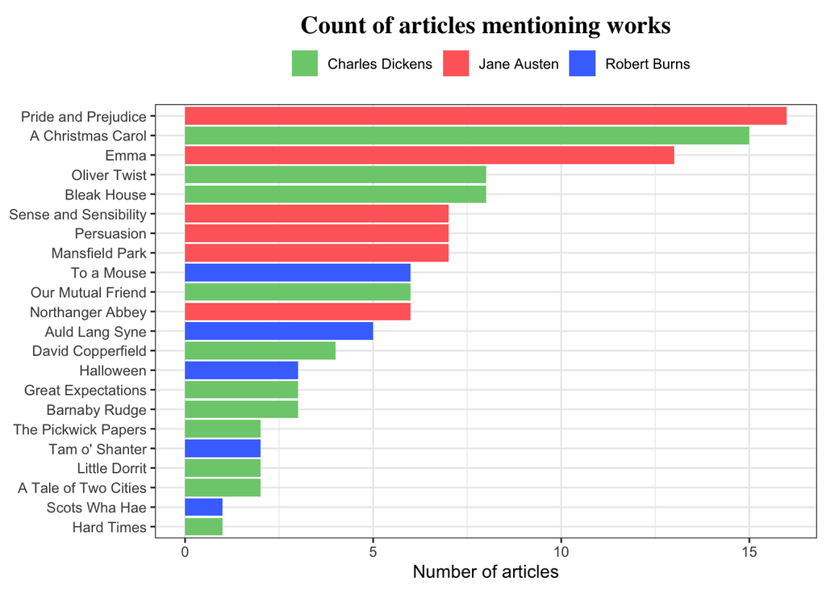

```r
ggplot(articles_analysis_summary , aes(x=reorder(notableWork, notableWorkCount, sum), y=notableWorkCount, fill=author))+
  geom_bar(stat="identity") +
  scale_fill_manual(name="Author", values = c("palegreen3","indianred1","royalblue1"))+
  coord_flip() +
  theme_bw() +
  labs(title = "Count of articles mentioning works", y = "Number of articles") +
  theme(plot.title = element_text(family="Times", hjust= 0.5, vjust=-0.4, face="bold", size=15),
        axis.title.y = element_blank(),
        legend.position = "top",
        legend.title = element_blank()
        )
```

#### Here we can see that the most referenced works are Pride and Prejudice and A Christmas Carol. Generally Burns’s works appear to be referenced less frequently, although perhaps this is to be expected given that they are poems rather than novels.

#### Next I will look at the top features mentioned in all newspaper articles by author

```r
# Filtering data to remove any articles where the full body of text is not provided
articles_analysis <- filter(articles_analysis, articles_analysis$body != "")

#Ingesting the html text into actual text
articles_analysis$body <- sapply(articles_analysis$body, function(x) html_text(read_html(x)))

#Creating a corpus
uk_article_corpus <- corpus(articles_analysis$body)
docvars(uk_article_corpus, "Author") <- articles_analysis$author

# Creating a grouped dfm matrix
uk_article_dfm_author <- uk_article_corpus %>%
    tokens(remove_punct = TRUE) %>%
    tokens_remove(stopwords("en")) %>%
    tokens_ngrams(n = 1:2) %>%
    dfm() %>%
    dfm_group(groups = Author)

# Obtaining the top 25 features per author
topfeatures(uk_article_dfm_author,25, groups=Author)
```

```
## $`Charles Dickens`
##         dickens             one       christmas            book         charles
##             412             154             150             111             105
##            like            just            time            said            also
##             105              95              93              91              91
##       dickens's            life charles_dickens           great             can
##              87              87              86              84              81
##          london          people              us           carol           first
##              76              74              74              70              69
##            read christmas_carol             new           story            even
##              69              69              68              66              65
##
## $`Jane Austen`
##          austen            jane             one        austen's            said
##             272             158             145             144              96
##           novel           first      photograph             can           pride
##              91              89              89              84              84
##            also       prejudice pride_prejudice            like     jane_austen
##              81              80              79              78              78
##             new              us          novels            emma            life
##              74              72              69              69              67
##             now           house          people              mr             two
##              66              63              61              60              59
##
## $`Robert Burns`
##        burns        scots     scottish          one       robert        first
##          156           67           58           41           38           33
##     scotland          man      burns's robert_burns         poet          now
##           32           30           30           29           28           25
##     language         time      english          can         year         like
##           25           24           24           23           23           22
##         many        poems     national          new       poetry        poets
##           22           22           21           21           21           21
##   macdiarmid
##           21
```

#### A few things stand out looking at the top features for each author:

#### Dickens - London is one of the words most commonly referenced in the newspaper articles. Dickens was a ‘great’ (another of the most common words in his articles) chronicler of London and so it should perhaps not be a suprise that this word features.

#### Austen - The words house, people, and mr all could be interpreted as reference to the typical setting of an Austen novel; the polite society of a country house.

#### Most notable among the Burns top features is how prominently nationality features. Both English and Scottish and the word ‘national’ feature. This is perhaps most interesting when contrasting with Dickens and Austen, for whom these words do not feature at all, despite both of them being considered English/British national icons.

#### Next I will look at the number of references for each author over time.

```r
# Getting books data from database
books_analysis <- dbGetQuery(db,
  "SELECT notable_works.author, uk_book_results.*
  FROM notable_works
  JOIN uk_book_results ON notable_works.notableWork = uk_book_results.notableWork")

# Binding tables into one dataset
mentions_over_time <- rbind(select(articles_analysis, all_of(c("author","publicationYear"))),select(books_analysis, all_of(c("author","publicationYear"))))

mentions_over_time <- mentions_over_time %>%
  group_by(author,publicationYear) %>%
  filter(publicationYear >= 2014 & publicationYear < 2022) %>%
  summarise(mentions = n())
```

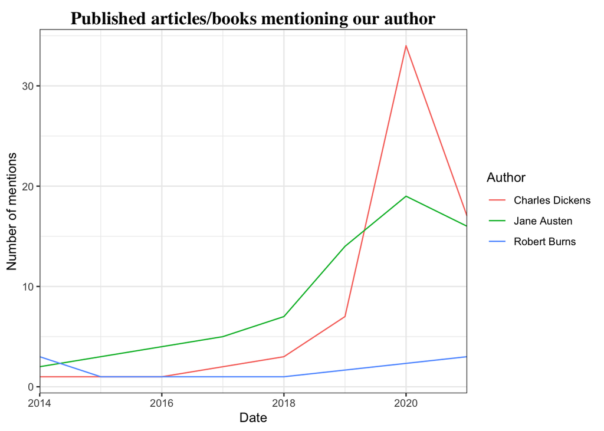

```r
ggplot(mentions_over_time, aes(x=publicationYear,y=mentions, group=author, color=author)) + geom_line() +
  theme_bw() +
  scale_colour_discrete(name = "Author") +
  scale_x_continuous(expand=c(0,0)) +
  labs(title = "Published articles/books mentioning our author", y = "Number of mentions", x="Date") +
  theme(plot.title = element_text(family="Times", hjust= 0.5, vjust=-0.4, face="bold", size=15)
        )
```